# Genome Assembly

Prof. Harbert

Meeting 16

# Genome Assembly

Challenge: Assemble a 1 billion piece puzzle where the pieces are all made of only 4 colors and repeated shapes.

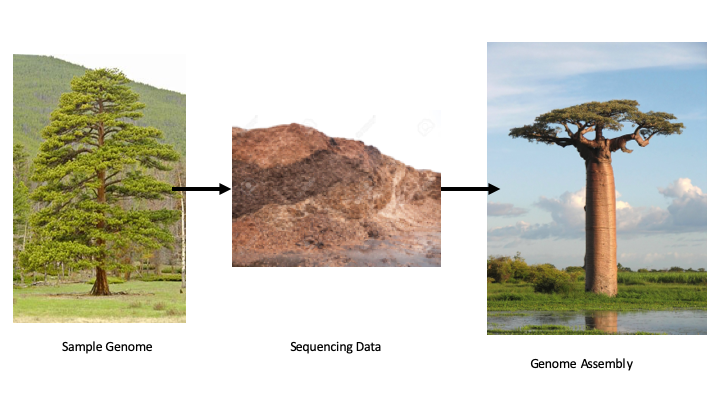

## Setup

In late December of 2019 doctors and scientists in Wuhan, China were tracking down the cause of an unknown respiritory virus. One part of this effort was to sequence RNA from bronchealveolar fluid from one of the patients. Those data are now available for us to work with:

[Data from 9 samples sequenced on December 30, 2019](https://www.ncbi.nlm.nih.gov/sra?linkname=bioproject_sra_all&from_uid=605983)

[Publication of the resulting genome](https://doi.org/10.1038/s41586-020-2012-7)

All of these samples are raw RNA sequencing data (represented here in the DNA alphabet) that were generated on an Illumina platform instrument resulting in paired end reads of 250 bp in length. This is a common, but tough, assembly scenario.

Let’s grab some of the data and see what we can do with it: [Don’t try to run this without verifying that you have several hundred GB of available storage space]

Here we will be working with SRR11092062 and SRR11092063. Each of these have data from two Illumina Hiseq 3000 runs and comprise a total of ~120 million read pairs (82GB of data), BUT consider that ~98% of this is probably human.

```bash
mkdir data

#hiseq
declare -a hiseq=( \
"https://sra-pub-sars-cov2.s3.amazonaws.com/sra-src/SRR11092062/v300043428_L02_127_1.fq.gz" \
"https://sra-pub-sars-cov2.s3.amazonaws.com/sra-src/SRR11092062/v300043428_L02_127_2.fq.gz" \
"https://sra-pub-sars-cov2.s3.amazonaws.com/sra-src/SRR11092062/v300043428_L04_122_1.fq.gz" \
"https://sra-pub-sars-cov2.s3.amazonaws.com/sra-src/SRR11092062/v300043428_L04_122_2.fq.gz" \
"https://sra-pub-sars-cov2.s3.amazonaws.com/sra-src/SRR11092063/v300043428_L02_126_1.fq.gz" \
"https://sra-pub-sars-cov2.s3.amazonaws.com/sra-src/SRR11092063/v300043428_L02_126_2.fq.gz" \
"https://sra-pub-sars-cov2.s3.amazonaws.com/sra-src/SRR11092063/v300043428_L04_121_1.fq.gz" \
"https://sra-pub-sars-cov2.s3.amazonaws.com/sra-src/SRR11092063/v300043428_L04_121_2.fq.gz" \
)

for file in "${hiseq[@]}"
do
  echo $file "\n"
  # parse the SRA id number
  SRA=$(echo $file | cut -d '/' -f5)
  echo $SRA
  #parse 1 or 2
  READSET=$(echo $file | cut -d '_' -f4)
  LNUM=$(echo $file | cut -d '_' -f2)
  echo $LNUM
  echo $READSET
  # get the data
  wget -bqc -o log.txt --output-document data/$SRA.$LNUM.$READSET "$file"
done

ls data/*fq.gz | xargs -P 4 -n 1 gunzip {}

cat data/*.1.fq > data/all_reads.R1.fq
cat data/*.2.fq > data/all_reads.R2.fq
```

## QC

Evaluate the read qualities for this dataset using fastqc. Are there any red flags?

```bash
fastqc -t 2 data/all_reads.R1.fq data/all_reads.R2.fq
```

## Cleaning up our Data

In any genome assembly you are going to have a hard time getting clean assembly graphs when you have material from more than one organism. Our data here are “metatranscriptomic” meaning that we have RNA from many organisms (of course some of this RNA is from an RNA genome so not *technically* transcribed). Much of this is probably from the host (humans), some maybe RNA from microbiome bacteria, and some is hopefully from our virus of interest.

The single biggest thing we can do to help our chances of assembly will be to remove the major contaminants. In this case we should remove any reads that map to the human genome. For this we will use the GRCh38 (https://www.ncbi.nlm.nih.gov/genome/guide/human/) reference genome indexed for alignment with bwa.

[Don’t run this:]

```bash
# download the reference FASTA file
wget --output-document data/human_ref.fna.gz https://ftp.ncbi.nlm.nih.gov/refseq/H_sapiens/annotation/GRCh38_latest/refseq_identifiers/GRCh38_latest_genomic.fna.gz

#unzip the compressed fna.gz to raw fna file
gunzip data/human_ref.fna.gz

# index with BWA (runs several hours)
bwa index data/human_ref.fna
```

Now that we have an index of a genome we can align with bwa and use samtools to filter reads the DON’T align. That is, we want to collect reads that find no match in the human genome because we are looking for a virus in a haystack of human transcripts.

[DON’T RUN THIS: Est time to align is several hours using 8 cores]

```bash
#align with bwa mem
bwa mem -t 8 data/human_ref.fna data/all_reads.R1.fq data/all_reads.R2.fq > data/all_reads.sam

# samtools: filter reads that DO NOT map to the reference and convert to fastq
#convert to BAM
samtools view -@ 8 -S -b data/all_reads.sam > data/all_reads.bam
#sort
samtools sort -@ 8 -o data/all_reads.sort.bam data/all_reads.bam
#output unmapped read pairs
samtools view -@ 8 -u -f 12 -F 256 data/all_reads.sort.bam > data/unmapped.bam
samtools fastq -@ 8 data/unmapped.bam -1 data/unmapped.R1.fq -2 data/unmapped.R2.fq

du -sh data/unmapped.*.fq
```

[output not shown]